# Proportional hazards regression with tabular data

Göran Broström

2026-06-01

The obvious way to handle that situation is by tabulation and applying a *piecewise constant hazard* function, because it is a well-known fact that any continuous function can arbitrary well be approximated by a step function, simply by taking small enough steps.

# 1 Tabular data

The first few rows of each:

```r
head(swepop)
```

```
##          age   sex year   pop  id
## 102.1969   0 women 1969 52673 102
## 1.1969     0   men 1969 55728   1
## 103.1969   1 women 1969 56831 103
## 2.1969     1   men 1969 59924   2
## 104.1969   2 women 1969 58994 104
## 3.1969     2   men 1969 62502   3
```

```r
head(swedeaths)
```

```
##        age   sex year deaths id
## 2.1969   0 women 1969    491  2
## 1.1969   0   men 1969    773  1
## 4.1969   1 women 1969     33  4
## 3.1969   1   men 1969     45  3
## 6.1969   2 women 1969     22  6
## 5.1969   2   men 1969     43  5
```

The funny rownames and the column `id` are created by the function `reshape`, which was used to transform the original tables, given in *wide format*, to *long format*. In the original data, downloaded from [Statistics Sweden](https://www.scb.se), the population size refers to the last day, December 31, of the given year, but here it refers to an average of that value and the corresponding one the previous year. In that way we get an estimate of the number of *person years*, which allows us to consider number of *occurrences* and *exposure time* in each cell of the data. This information will allow us to fit *proportional hazards* survival models. So we start by joining the two data sets and remove irrelevant stuff:

```r
dat <- swepop[, c("age", "sex", "year", "pop")]
dat$deaths <- swedeaths$deaths
rownames(dat) <- 1:NROW(dat) # Simplify rownames.
head(dat)
```

```
##   age   sex year   pop deaths
## 1   0 women 1969 52673    491
## 2   0   men 1969 55728    773
## 3   1 women 1969 56831     33
## 4   1   men 1969 59924     45
## 5   2 women 1969 58994     22
## 6   2   men 1969 62502     43
```

```r
tail(dat)
```

```
##       age   sex year    pop deaths
## 10499  98 women 2020 2033.5    764
## 10500  98   men 2020  578.5    301
## 10501  99 women 2020 1445.0    581
## 10502  99   men 2020  367.0    178
## 10503 100 women 2020 1933.5   1004
## 10504 100   men 2020  394.5    243
```

## 1.1 Poission regression

Assuming a piecewise constant hazards model on the 101 age groups, we can fit a proportional hazards model by *Poisson regression*, utilizing the fact that two likelihood functions in fact are identical. In **R**, we use `glm`.

```r
fit.glm <- glm(deaths ~ offset(log(pop)) + I(year - 2000) + sex +
                 factor(age), data = dat, family = poisson)
summary(fit.glm)$coefficients[2:3, ]
```

```
##                Estimate Std. Error z value Pr(>|z|)
## I(year - 2000) -0.01497  3.136e-05  -477.5        0
## sexmen          0.43997  9.304e-04   472.9        0
```

The 101 coefficients corresponding to the intercept and the age factor can be used to estimate the *hazard function*: The intercept, -5.6181, is the log of the hazard in the age interval 0-1, and the rest are differences to that value, so we can reconstruct the baseline hazard by

```r
lhaz <- coefficients(fit.glm)[-(2:3)]
n <- length(lhaz)
lhaz[-1] <- lhaz[-1] + lhaz[1]
haz <- exp(lhaz)
```

and plot the result, see Figure 1.1.

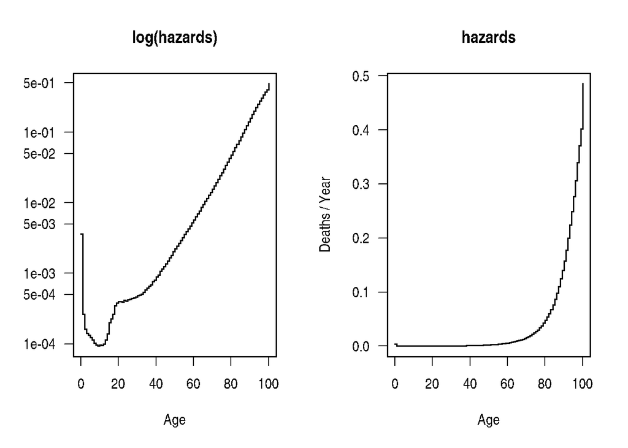

```r
oldpar <- par(las = 1, lwd = 1.5, mfrow = c(1, 2))
plot(0:(n-1), haz, type = "s", main = "log(hazards)",
     xlab = "Age", ylab = "", log = "y")
plot(0:(n-1), haz, type = "s", main = "hazards",
     xlab = "Age", ylab = "Deaths / Year")
```

## 1.2 The tpchreg function

While it straightforward to use glm and Poisson regression to fit the model, it takes some efforts to get it right. That is the reason for the creation of the function `tpchreg` (“Tabular Piecewise Constant Hazards REGression”), and with it, the “Poisson analysis” is performed by

```r
fit <- tpchreg(oe(deaths, pop) ~ I(year - 2000) + sex,
               time = age, last = 101, data = dat)
```

Note:

- The function `oe` (“occurrence/exposure”) takes two arguments, the first is the number of events (deaths in our example), and the second is exposure time, or person years.
- The argument `time` is the defining time intervals variable. It can be either character, like c(“0-1”, “1-2”, …, “100-101”) or numeric (as here). If numeric, the value refers to the start of the corresponding interval, and the next start is the end of the previous interval. This leaves the last interval’s endpoint undefined, and if not given by the `last` argument (see below), it is chosen so that the length of the last interval is one.
- The argument `last` closes the last interval, if is not already closed, see above. The exact value of last is only important for plotting and for the calculation of the *restricted mean survival time*, (RMST) see the summary result below.

```r
summary(fit)
```

```
## Covariate             Mean       Coef     Rel.Risk   S.E.    LR p
## I(year - 2000)       -4.480    -0.015     0.985     0.000    0.000
## sex                                                          0.000
##            women      0.503     0         1 (reference)
##              men      0.497     0.440     1.553     0.001
##
## Events                    4745063
## Total time at risk        459651727
## Max. log. likelihood      -19283067
## LR test statistic         443018.82
## Degrees of freedom        2
## Overall p-value           0
##
## Restricted mean survival:  81.58 in (0, 101]
```

The restricted mean survival time is defined as the integral of the survivor function over the given time interval. Note that if the lower limit of the interval is larger than zero, it gives the *conditional* restricted mean survival time, given survival to the lower endpoint.

Graphs of the hazards and the log(hazards) functions are shown in Figure 1.2.

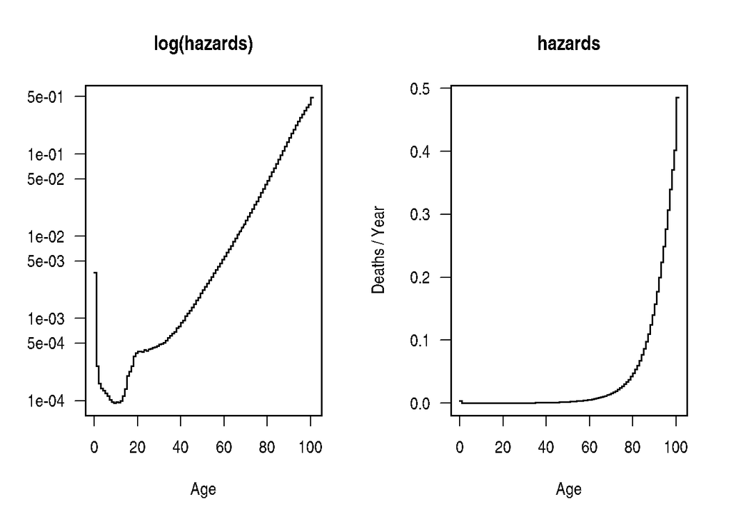

```r
oldpar <- par(mfrow = c(1, 2), las = 1, lwd = 1.5)
plot(fit, fn = "haz", log = "y", main = "log(hazards)",
     xlab = "Age")
plot(fit, fn = "haz", log = "", main = "hazards",
     xlab = "Age", ylab = "Deaths / Year")
```

Same results as with `glm` and Poisson regression, but a lot simpler.